## Course: Estadística Para el Análisis Político II Semestre 2017-II

### Prof. José Manuel Magallanes, PhD

## **Análisis Multivariado**

## Técnicas Descriptivas y Exploratorias (Parte II)

Trabajemos con los datos ya limpios de la sesión [anterior](https://rawgit.com/PoliticayGobiernoPUCP/EstadisticaPoliticaGobiernoII/master/sesiones/ClusterAnalysis_class_Peru.html) presentes en un archivo Excel (descargar aqui):

```r
library(openxlsx)
folder='data'
fileName='IDE_limpio.xlsx'
fileToRead=file.path(folder,fileName)
provinciasNew=read.xlsx(fileToRead)
```

```r
head(provinciasNew)
```

```
##   regionUbigeo provinciaUbigeo regionNombre      provinciaNombre pob2012
## 1       010000          010200     AMAZONAS                Bagua   77438
## 2       010000          010300     AMAZONAS              Bongará   32317
## 3       010000          010400     AMAZONAS         Condorcanqui   51802
## 4       010000          010500     AMAZONAS                 Luya   52185
## 5       010000          010600     AMAZONAS Rodríguez de Mendoza   30236
## 6       010000          010700     AMAZONAS            Utcubamba  118747
##     ide2012 identificacion2012 medicos2012 escolaridad2012 AguaDesague2012
## 1 0.6622805           94.60787   14.609121        79.79018        64.47904
## 2 0.6318249           97.46807    9.010207        76.42404        54.83408
## 3 0.4598242           86.23196    8.556959        52.21494        37.71451
## 4 0.6047198           96.19272   12.418003        74.72597        43.34842
## 5 0.6312264           97.34310   14.878682        79.42439        46.50182
## 6 0.6096605           95.17449   10.110167        77.16833        52.51951
##   electrificacion2012
## 1            67.91462
## 2            72.16926
## 3            39.48908
## 4            67.39611
## 5            67.54610
## 6            63.11765
```

En la sesión anterior vimos cómo aplicar la técnica jerarquica a estos datos:

1. Quedemonos con las columnas que necesitamos:

```r
columnasUtilizar=c(7:11)
df=provinciasNew[columnasUtilizar]
```

2. Usar el nombre de provincia como la etiqueta de la fila:

```r
row.names(df)=provinciasNew$provinciaNombre
head(df)
```

```
##                      identificacion2012 medicos2012 escolaridad2012
## Bagua                          94.60787   14.609121        79.79018
## Bongará                        97.46807    9.010207        76.42404
## Condorcanqui                   86.23196    8.556959        52.21494
## Luya                           96.19272   12.418003        74.72597
## Rodríguez de Mendoza           97.34310   14.878682        79.42439
## Utcubamba                      95.17449   10.110167        77.16833
##                      AguaDesague2012 electrificacion2012
## Bagua                       64.47904            67.91462
## Bongará                     54.83408            72.16926
## Condorcanqui                37.71451            39.48908
## Luya                        43.34842            67.39611
## Rodríguez de Mendoza        46.50182            67.54610
## Utcubamba                   52.51951            63.11765
```

2. Llevarlos datos a utilizar a una unidad comun ( o sin unidad de medida):

```r
df.scaled=scale(df)
```

3. Crear ‘distancias’ entre las filas usando la información multivariada (ahora no lo haremos pues NbClust lo hace).
4. Tratar de identificar el numero de clusters que se necesitarán:
- NbClust puede proponer cuantos clusters proponer (en este caso siendo metodo jerarquico):

```r
library(NbClust)
nb <- NbClust(df.scaled, method = "complete") # 'hclust' usa metodo 'complete' por default.
```

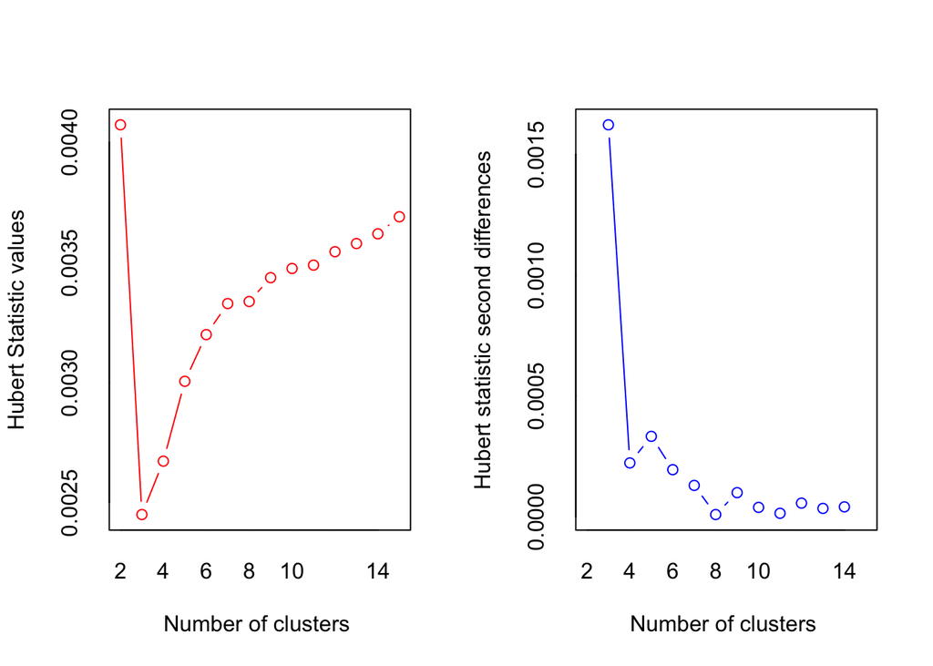

```
## *** : The Hubert index is a graphical method of determining the number of clusters.
##                 In the plot of Hubert index, we seek a significant knee that corresponds to a
##                 significant increase of the value of the measure i.e the significant peak in Hubert
##                 index second differences plot.
##
```

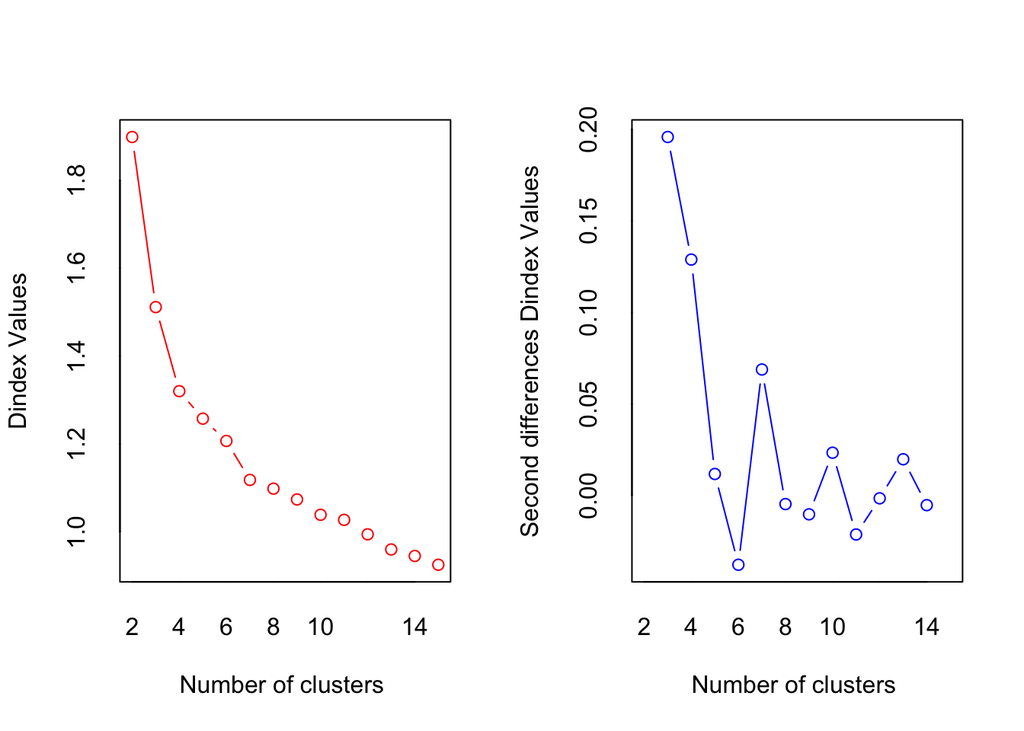

```
## *** : The D index is a graphical method of determining the number of clusters.
##                 In the plot of D index, we seek a significant knee (the significant peak in Dindex
##                 second differences plot) that corresponds to a significant increase of the value of
##                 the measure.
##
## * Among all indices:
## * 6 proposed 2 as the best number of clusters
## * 9 proposed 3 as the best number of clusters
## * 5 proposed 4 as the best number of clusters
## * 2 proposed 5 as the best number of clusters
## * 1 proposed 13 as the best number of clusters
## * 1 proposed 15 as the best number of clusters
##
##                    ***** Conclusion *****
##
## * According to the majority rule, the best number of clusters is  3
##
##
```

- De ahí que el numero sugerido es:

```r
length(table(nb$Best.partition))
```

```
## [1] 3
```

5. Aplicar el **algoritmo** deseado, sabiendo cuantos clusters pedir:

```r
library(factoextra)
```

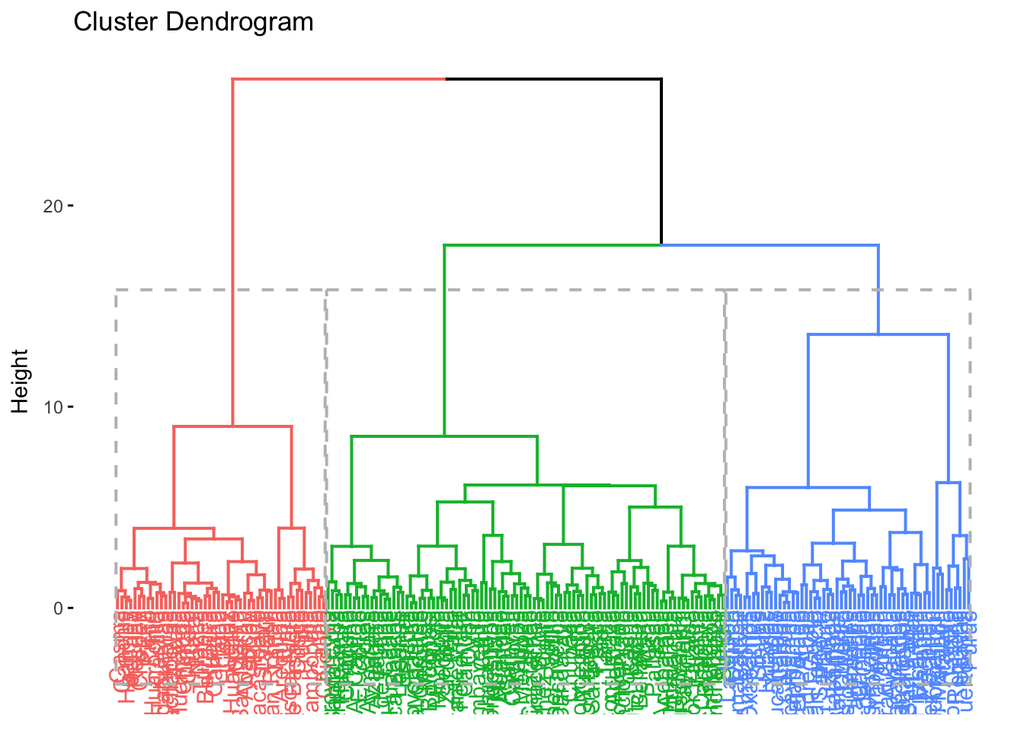

```r
algoritmo="hclust"
cuantosClusters=length(table(nb$Best.partition))
solucionJerarquica1 <- eclust(df.scaled,
                              FUNcluster =algoritmo,
                              k = cuantosClusters,
                              method = "complete", # como en nb!
                              graph = FALSE)

fviz_dend(solucionJerarquica1, rect = TRUE, show_labels = T)
```

6. Evaluar qué tan buena ha sido nuestra aglomeración:

```
##   cluster size ave.sil.width
## 1       1   91          0.27
## 2       2   56          0.16
## 3       3   48          0.41
```

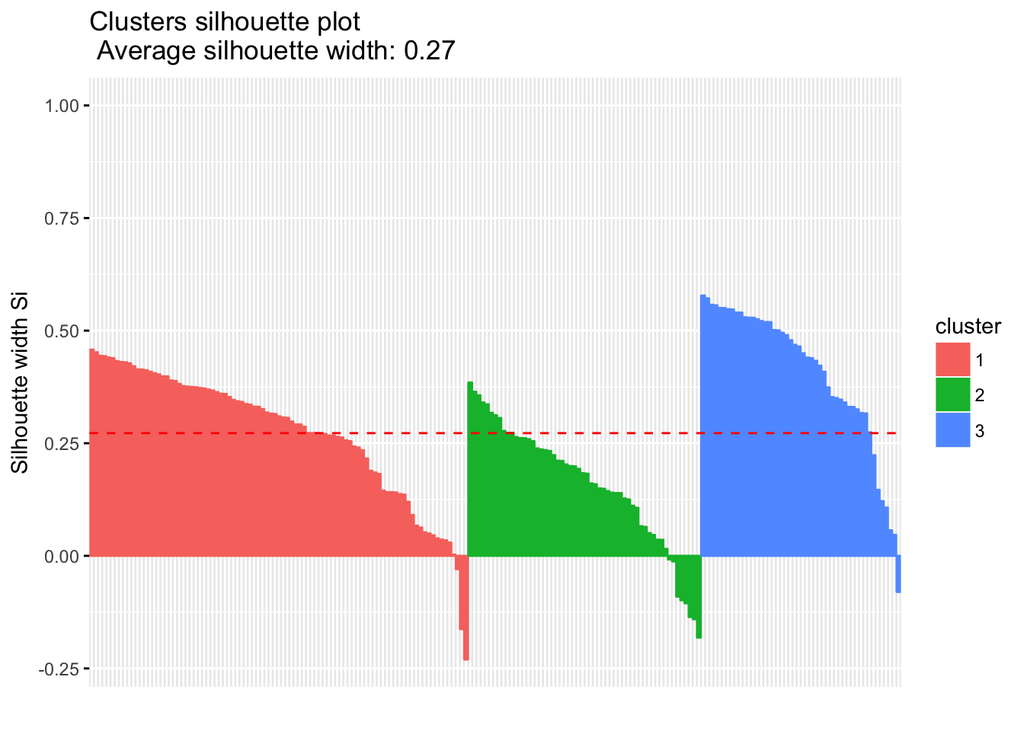

```r
# Un valor cercano a **uno** indica que el valor está bien aglomerado, si está cercano a cero indica que esta entre dos conglomerados, y si es negativo, que está en un cluster erróneo (al algoritmo acabó y no pudo ubicarlo en el grupo adecuado).

fviz_silhouette(solucionJerarquica1)
```

7. El objeto *solucionJerarquica1* guarda la información de silueta. Cada provincia tiene su propio valor. Podemos detectar qué provincia no ha sido bien conglomerada:

```r
siluetasPorProvincia <-solucionJerarquica1$silinfo$widths

# quedarse con las negativas para ver que provincias tiene problemas:
siluetasPorProvincia[siluetasPorProvincia$sil_width<0,]
```

```
##                      cluster neighbor    sil_width
## Paucar del Sara Sara       1        3 -0.029485712
## Huánuco                    1        3 -0.162745955
## Tahuamanú                  1        3 -0.230168491
## Paruro                     2        1 -0.007983778
## Lamas                      2        1 -0.012407030
## San Miguel                 2        1 -0.090568597
## Ambo                       2        1 -0.098618357
## Huaylas                    2        1 -0.105335588
## Luya                       2        1 -0.135692443
## Sihuas                     2        1 -0.140644894
## Chota                      2        1 -0.181545362
## Recuay                     3        1 -0.080046984
```

8. Podemos reintentar lo anterior, cambiando los parámetros de la función **scale**, pues los valores por defecto de esa función son la media y la desviación típica (lo que dió z-scores); pero, podríamos usar las medianas y la desviaciónes de la mediana en vez de ellas:

```r
medians = apply(df,2,median)
mads = apply(df,2,mad)
df.scaled2 = scale(df,center=medians,scale=mads)

# aplicando Nb:
nb2 <- NbClust(df.scaled2, method = "complete")
```

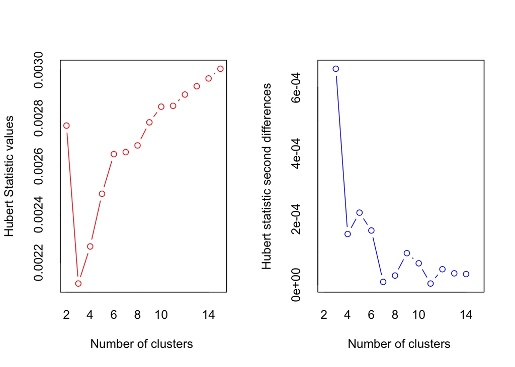

```
## *** : The Hubert index is a graphical method of determining the number of clusters.
##                 In the plot of Hubert index, we seek a significant knee that corresponds to a
##                 significant increase of the value of the measure i.e the significant peak in Hubert
##                 index second differences plot.
##
```

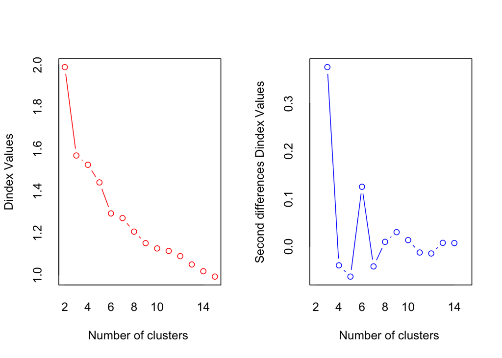

```
## *** : The D index is a graphical method of determining the number of clusters.
##                 In the plot of D index, we seek a significant knee (the significant peak in Dindex
##                 second differences plot) that corresponds to a significant increase of the value of
##                 the measure.
##
## * Among all indices:
## * 6 proposed 2 as the best number of clusters
## * 14 proposed 3 as the best number of clusters
## * 2 proposed 5 as the best number of clusters
## * 2 proposed 15 as the best number of clusters
##
##                    ***** Conclusion *****
##
## * According to the majority rule, the best number of clusters is  3
##
##
```

```r
# aplicando eclust sabiendo cantidad de clusters:
cuantosClusters2=length(table(nb2$Best.partition))
solucionJerarquica2 <- eclust(df.scaled2,
                              FUNcluster =algoritmo,
                              k = cuantosClusters2,
                              method = "complete", # como en nb!
                              graph = FALSE)
```

Hasta aqui tendriamos dos resultados. Valdría la pena saber qué tan coincidentes han sido:

```r
# calculado con puntuacionez z (media y desv tipica)
ideMedia=as.data.frame(solucionJerarquica1$cluster)

# calculado con puntuacionez mediana y des de la mediana
ideMediana=as.data.frame(solucionJerarquica2$cluster)
```

Veamos cuantos hay en cada uno:

```r
table(ideMedia)
```

```
## ideMedia
##  1  2  3
## 91 56 48
```

```r
table(ideMediana)
```

```
## ideMediana
##   1   2   3
## 134   9  52
```

Vemos que los resultados son *MUY* diferentes. Si hay presencia de atípicos, usar la mediana tendría más sentido.

## TECNICA K-MEDIAS

Podriamos reintentar clusterizar usando una tecnica alternativa. La técnica k-medias te solicita la cantidad de clusters que requieres, con fines comparativos pidamos 3:

```r
algoritmo="kmeans"
cuantosClusters=3
solucionKmeans1 <- eclust(df.scaled,
                          FUNcluster =algoritmo,
                          k = cuantosClusters, # como en nb!
                          graph = FALSE)
```

Si dibujasemos la solución NO tendríamos un dendograma, sino un mapa de provincias que las separa y junta según la cercanía/lejanía entre sus perfiles en el IDE (comparar con escalamiento óptimo en la siguiente sesión).

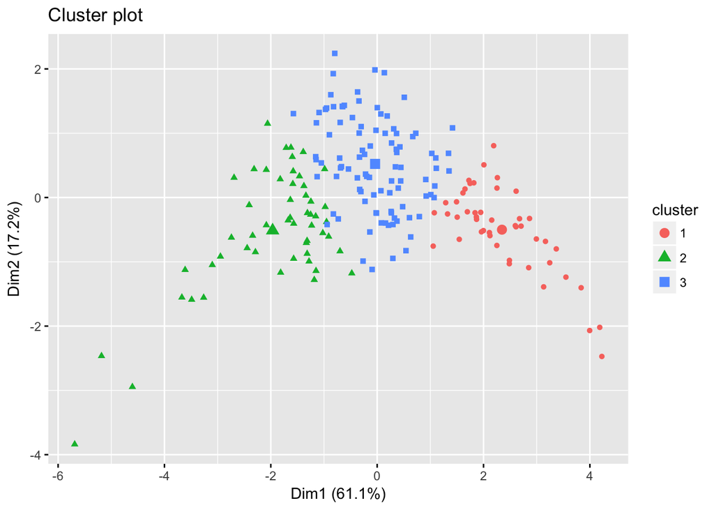

```r
fviz_cluster(solucionKmeans1, geom = "point", ellipse = F)
```

Podemos ver la performance de la técnica en esta data:

```
##   cluster size ave.sil.width
## 1       1   46          0.42
## 2       2   53          0.17
## 3       3   96          0.29
```

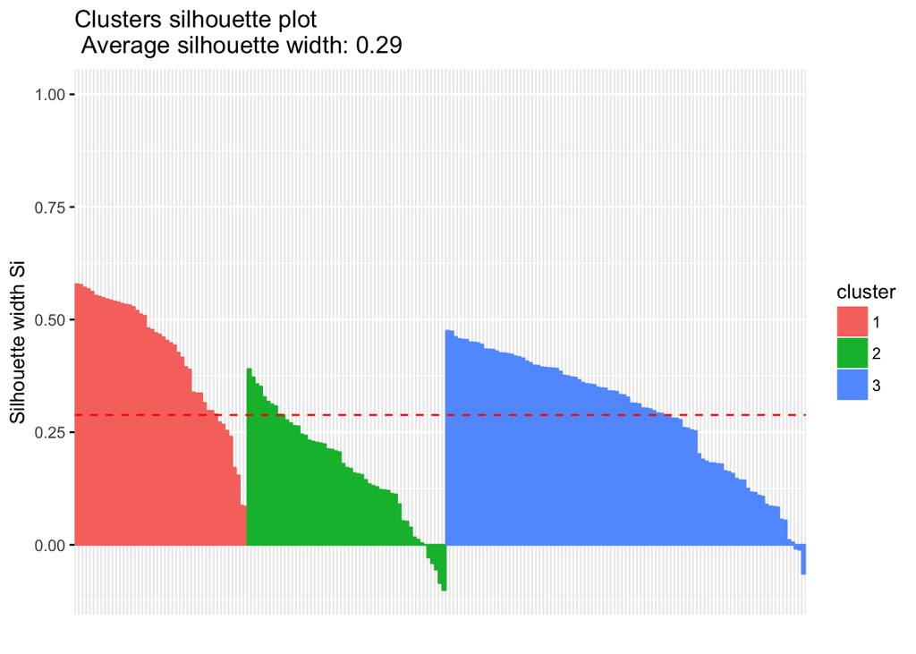

```r
fviz_silhouette(solucionKmeans1)
```

Y nuevamente identificar los pobremente agrupados:

```r
siluetasPorProvincia <-solucionKmeans1$silinfo$widths

# quedarse con las negativas:
siluetasPorProvincia[siluetasPorProvincia$sil_width<0,]
```

```
##             cluster neighbor     sil_width
## Cangallo          2        3 -0.0003014385
## Lamas             2        3 -0.0278815757
## Paruro            2        3 -0.0405800275
## Manú              2        3 -0.0547122644
## Utcubamba         2        3 -0.0845866649
## Bellavista        2        3 -0.1003152596
## Andahuaylas       3        1 -0.0083392252
## Pisco             3        1 -0.0106442083
## Canchis           3        1 -0.0642255093
```

Igual que antes, podemos guardar los clusters:

```r
ideK=as.data.frame(solucionKmeans1$cluster)
```

Como fue la distribución aquí:

```r
table(ideK)
```

```
## ideK
##  1  2  3
## 46 53 96
```

A esta altura debemos recordar que los numeros asignados no representan necesariamente un orden. Lo mejor será juntar toda la data:

```r
provinciasClust=merge(provinciasNew,ideMedia,
                 by.x = 'provinciaNombre',
                 by.y=0) # 'by.y=0' está usando los row.names
head(provinciasClust)
```

```
##   provinciaNombre regionUbigeo provinciaUbigeo regionNombre pob2012
## 1         Abancay       030000          030100     APURÍMAC  105694
## 2        Acobamba       090000          090200 HUANCAVELICA   73243
## 3         Acomayo       080000          080200        CUSCO   28318
## 4            Aija       020000          020200       ANCASH    7974
## 5   Alto Amazonas       160000          160200       LORETO  117163
## 6            Ambo       100000          100200      HUÁNUCO   57957
##     ide2012 identificacion2012 medicos2012 escolaridad2012 AguaDesague2012
## 1 0.7466421           97.90419   16.931097        93.69086        63.00113
## 2 0.5771310           98.75156    2.628194        77.54075        31.17210
## 3 0.6331165           97.19903   10.453706        83.12670        48.23934
## 4 0.6579253           98.23439    8.593985        89.49891        47.78407
## 5 0.5685318           94.03978   10.813959        61.71118        44.49094
## 6 0.5594230           97.92044   11.182912        74.88339        25.58357
##   electrificacion2012 solucionJerarquica1$cluster
## 1            90.50638                           3
## 2            76.72076                           1
## 3            70.57030                           1
## 4            79.12196                           1
## 5            66.00075                           2
## 6            62.68590                           2
```

El comando anterior creó una columna nueva, asi que hay que modificar los nuevos merges:

```r
provinciasClust=merge(provinciasClust,ideMediana,
                      by.x='provinciaNombre',
                      by.y=0)

provinciasClust=merge(provinciasClust,ideK,
                      by.x='provinciaNombre',
                      by.y=0)
```

Aquí está todo junto:

```r
names(provinciasClust)
```

```
##  [1] "provinciaNombre"             "regionUbigeo"
##  [3] "provinciaUbigeo"             "regionNombre"
##  [5] "pob2012"                     "ide2012"
##  [7] "identificacion2012"          "medicos2012"
##  [9] "escolaridad2012"             "AguaDesague2012"
## [11] "electrificacion2012"         "solucionJerarquica1$cluster"
## [13] "solucionJerarquica2$cluster" "solucionKmeans1$cluster"
```

Hagamos un ajuste a los nombres:

```r
# Cambiemos los nombres:
nuevosNom=c('j1','j2','k1')
names(provinciasClust)[c(12:14)]=nuevosNom
```

Podriamos ver unas tablas ahora:

```r
table(provinciasClust$j1,provinciasClust$j2)
```

```
##
##      1  2  3
##   1 87  0  4
##   2 47  9  0
##   3  0  0 48
```

```r
table(provinciasClust$j1,provinciasClust$k1)
```

```
##
##      1  2  3
##   1  2  3 86
##   2  0 50  6
##   3 44  0  4
```

```r
table(provinciasClust$j2,provinciasClust$k1)
```

```
##
##      1  2  3
##   1  1 44 89
##   2  0  9  0
##   3 45  0  7
```

## Mapas y clusters

Traigamos un mapa ahora:

```r
folder='data'
folderMap='PER_adm_shp'
fileName='PER_adm2.shp' # nivel 2 son provincias
fileToRead=file.path(folder,folderMap,fileName)

library(rgdal)
PeruProvs <- rgdal::readOGR(fileToRead,stringsAsFactors=FALSE)
```

Sin problema, el mapa se dibujará.

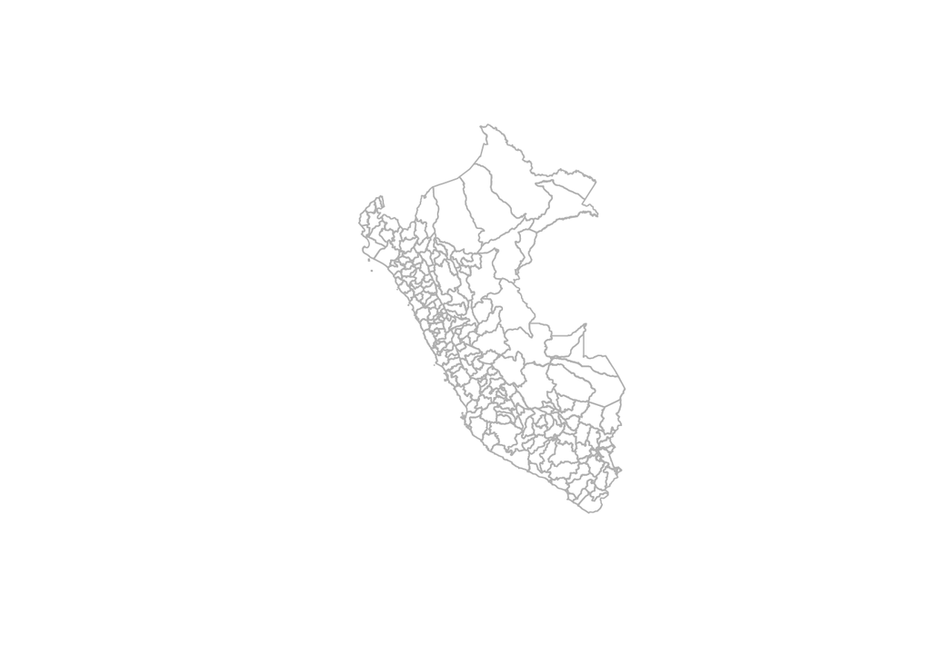

```r
plot(PeruProvs, border='grey')
```

Ambos tiene 195 filas. Veamos como se identifican las provincias:

```r
head(PeruProvs@data)
```

```
##   ID_0 ISO NAME_0 ID_1   NAME_1 ID_2               NAME_2   HASC_2 CCN_2
## 0  178 PER   Peru    1 Amazonas    1                Bagua PE.AM.BG     0
## 1  178 PER   Peru    1 Amazonas    2              Bongará PE.AM.BN     0
## 2  178 PER   Peru    1 Amazonas    3          Chachapoyas PE.AM.CP     0
## 3  178 PER   Peru    1 Amazonas    4         Condorcanqui PE.AM.CQ     0
## 4  178 PER   Peru    1 Amazonas    5                 Luya PE.AM.LY     0
## 5  178 PER   Peru    1 Amazonas    6 Rodríguez de Mendoza PE.AM.RM     0
##   CCA_2    TYPE_2 ENGTYPE_2 NL_NAME_2            VARNAME_2
## 0  <NA> Provincia  Province      <NA>                 <NA>
## 1  <NA> Provincia  Province      <NA>              Bongart
## 2  <NA> Provincia  Province      <NA>                 <NA>
## 3  <NA> Provincia  Province      <NA>                 <NA>
## 4  <NA> Provincia  Province      <NA>                 <NA>
## 5  <NA> Provincia  Province      <NA> Rodreguez de Mendoza
```

Podemos ver que en NAME_2 estan los nombres de provincias (ordenados):

```r
sort(PeruProvs@data$NAME_2)
```

```
##   [1] "Abancay"                   "Acobamba"
##   [3] "Acomayo"                   "Aija"
##   [5] "Alto Amazonas"             "Ambo"
##   [7] "Andahuaylas"               "Angaraes"
##   [9] "Anta"                      "Antabamba"
##  [11] "Antonio Raymondi"          "Arequipa"
##  [13] "Ascope"                    "Asunción"
##  [15] "Atalaya"                   "Ayabaca"
##  [17] "Aymaraes"                  "Azángaro"
##  [19] "Bagua"                     "Barranca"
##  [21] "Bellavista"                "Bolívar"
##  [23] "Bolognesi"                 "Bongará"
##  [25] "Cajabamba"                 "Cajamarca"
##  [27] "Cajatambo"                 "Calca"
##  [29] "Callao"                    "Camaná"
```

[output cut: 83 more lines]

Se parecen a los que tenemos?

```r
provinciasClust$provinciaNombre
```

```
##   [1] "Abancay"                   "Acobamba"
##   [3] "Acomayo"                   "Aija"
##   [5] "Alto Amazonas"             "Ambo"
##   [7] "Andahuaylas"               "Angaraes"
##   [9] "Anta"                      "Antabamba"
##  [11] "Antonio Raymondi"          "Arequipa"
##  [13] "Ascope"                    "Asunción"
##  [15] "Atalaya"                   "Ayabaca"
##  [17] "Aymaraes"                  "Azángaro"
##  [19] "Bagua"                     "Barranca"
##  [21] "Bellavista"                "Bolívar"
##  [23] "Bolognesi"                 "Bongará"
##  [25] "Cajabamba"                 "Cajamarca"
##  [27] "Cajatambo"                 "Calca"
##  [29] "Callao"                    "Camaná"
```

[output cut: 83 more lines]

Parece que sí, pero no sabremos que tan bien saldra el merge si no lo hacemos; probemos:

```r
test=merge(PeruProvs@data,provinciasClust,by.x='NAME_2',by.y='provinciaNombre',all.x=T)
```

Cuando no hay coincidencias, merge crea un valor NA (missing). Aqui detecto que filas del mapa no encontraron coincidencias:

```r
test[is.na(test$ide2012),]
```

```
##                        NAME_2 ID_0 ISO NAME_0 ID_1        NAME_1 ID_2
## 40  Carlos Fermin Fitzcarrald  178 PER   Peru    2        Ancash   13
## 53                   Chucuíto  178 PER   Peru   22          Puno  163
## 67     Daniel Alcides Carrión  178 PER   Peru   20         Pasco  150
## 79                  Huamalíes  178 PER   Peru    9       Huánuco   84
## 83                   Huancane  178 PER   Peru   22          Puno  165
## 91                 Huarochiri  178 PER   Peru   16          Lima  134
## 94                   Huaytara  178 PER   Peru   10  Huancavelica   97
## 95                    Huenuco  178 PER   Peru    9       Huánuco   85
## 102                    Julcan  178 PER   Peru   13   La Libertad  117
## 107             Lago Titicaca  178 PER   Peru   22          Puno  166
## 117                      Manu  178 PER   Peru   18 Madre de Dios  144
## 132                      Oyon  178 PER   Peru   16          Lima  136
## 169                    Satipo  178 PER   Peru   12         Junín  110
## 175                 Tahuamanu  178 PER   Peru   18 Madre de Dios  145
```

[output cut: 70 more lines]

Vemos que hay 16 provincias que no serían ploteadas, al menos que cambiemos los nombres en *provinciasClust*.

Si seguimos sin hacer los cambios:

```r
PeruProvs=merge(PeruProvs,provinciasClust,by.x='NAME_2',by.y='provinciaNombre',all.x=T)
```

Para graficar, deberiamos tener idea de la posicion de las provincias. Lima debe estar bien, quiero saber en que cluster está:

```r
PeruProvs@data[PeruProvs@data$NAME_2=='Lima',]$j1
```

```
## [1] 3
```

De igual forma, Atalaya debe estar entre los peores:

```r
PeruProvs@data[PeruProvs@data$NAME_2=='Atalaya',]$j1
```

```
## [1] 2
```

De ahi que sabemos que los mejores estan en el cluster ‘3’, los peores en el ‘2’, y los intermedios en el ‘1’.

Recodifiquemos facilmente con el paquete **car**:

```r
library(car)

# ejecutar (run) UNA VEZ!!!
PeruProvs@data$j1<-recode(PeruProvs@data$j1,"2=1;1=2") # usa ';'
```

Aquí si 1,2,3 van de menos a mas, y eso lo reflejo en la secuencia de colores a usar. Comparemos con el IDE original. Primero dividamos los valores en 3 intervalos:

```r
PeruProvs@data$ideCut=cut(PeruProvs@data$ide2012,
                       breaks=3,labels=c('1','2','3'))
```

Ahora sí grafiquemos:

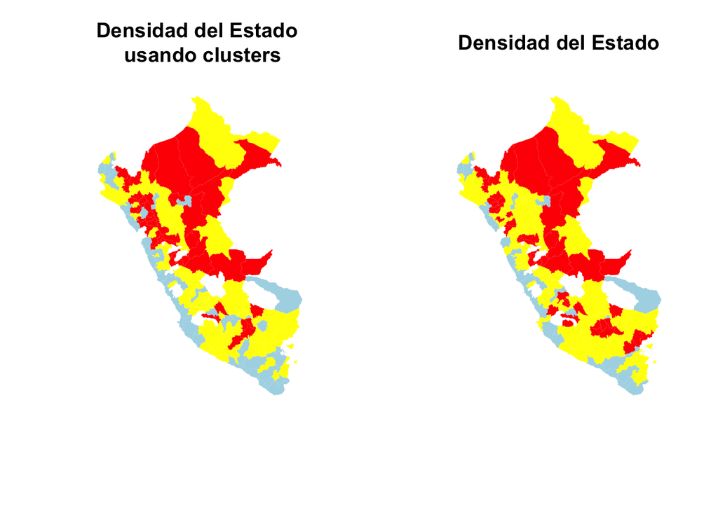

```r
# colores
myColors=c('red','yellow','lightblue')

# particionando
par(mfrow=c(1,2)) # 1 fila, 2 columnas
plot(PeruProvs,col=myColors[PeruProvs$j1], main='Densidad del Estado \n usando clusters',border=NA)
plot(PeruProvs,col=myColors[PeruProvs$ideCut],main='Densidad del Estado',border=NA)
```

Aqui están las no coincidencias:

```r
test2=PeruProvs@data
test2=test2[complete.cases(test2$ide2012),]
test2[test2$ideCut != test2$j1,]
```

```
##                    NAME_2 ID_0 ISO NAME_0 ID_1       NAME_1 ID_2   HASC_2
## 116                  Luya  178 PER   Peru    1     Amazonas    5 PE.AM.LY
## 41                  Casma  178 PER   Peru    2       Ancash   14 PE.AN.CA
## 93                Huaylas  178 PER   Peru    2       Ancash   19 PE.AN.HY
## 153                Recuay  178 PER   Peru    2       Ancash   24 PE.AN.RE
## 171                Sihuas  178 PER   Peru    2       Ancash   26 PE.AN.SH
## 193                Yungay  178 PER   Peru    2       Ancash   27 PE.AN.YN
## 1                 Abancay  178 PER   Peru    3     Apurímac   28 PE.AP.AB
## 7             Andahuaylas  178 PER   Peru    3     Apurímac   29 PE.AP.AH
## 10              Antabamba  178 PER   Peru    3     Apurímac   30 PE.AP.AN
## 75                   Grau  178 PER   Peru    3     Apurímac   34 PE.AP.GR
## 42               Castilla  178 PER   Peru    4     Arequipa   38 PE.AR.CT
## 106              La Unión  178 PER   Peru    4     Arequipa   42 PE.AR.LU
## 81          Huanca Sancos  178 PER   Peru    5     Ayacucho   45 PE.AY.HS
## 25              Cajabamba  178 PER   Peru    6    Cajamarca   54 PE.CJ.CJ
```

[output cut: 165 more lines]